# 615 Pre_EDA

### The analysis of BMI Based Categorisation

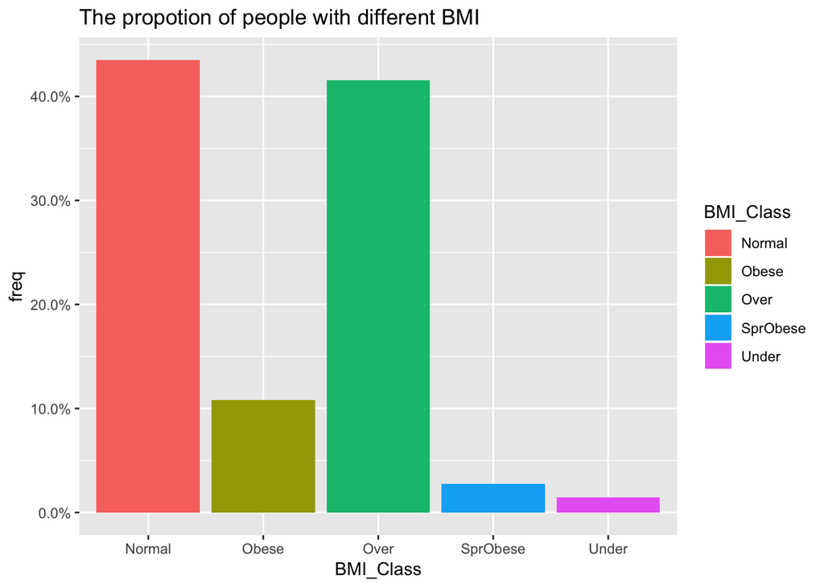

```r
frm_mod<- frm %>%
  mutate(BMI_Class=case_when(BMI<18.5~'Under',BMI >= 18.5 & BMI <25 ~ 'Normal',BMI >= 25 & BMI < 30 ~ 'Over',BMI>=30 & BMI<35 ~ 'Obese',BMI>=35 ~ 'SprObese'))

# SUMMARY OF Mean Heart Rates by BMI category
frm_bmi_hrt <- frm_mod %>% filter(!is.na(HEARTRTE) & !is.na(BMI)) %>%
  group_by(BMI_Class) %>%
  summarise (n = n(),mean_heart_rate=mean(HEARTRTE)) %>%
  mutate(freq = n / sum(n))
# the percentage of population with different BMI #
ggplot(frm_bmi_hrt,aes(BMI_Class,freq,fill=BMI_Class)) +
  geom_bar(stat="identity",position="dodge") +
  ggtitle("The propotion of people with different BMI") +
  scale_y_continuous(labels = percent)
```

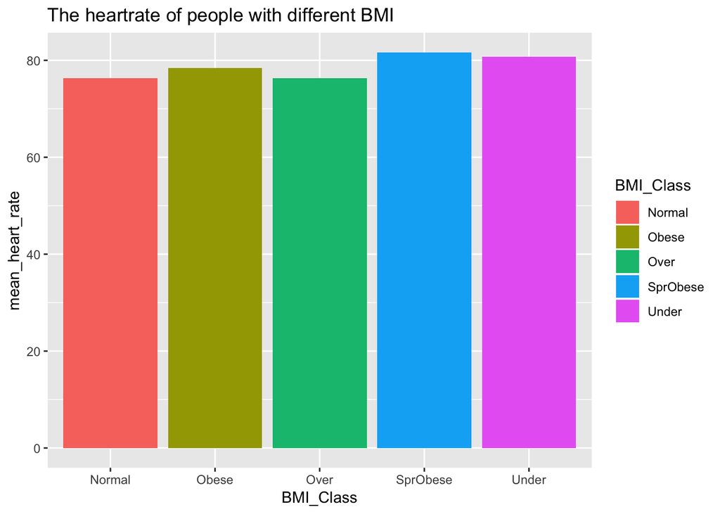

```r
ggplot(frm_bmi_hrt,aes(BMI_Class,mean_heart_rate,fill=BMI_Class)) +
  geom_bar(stat="identity",position="dodge") +
  ggtitle("The heartrate of people with different BMI")
```

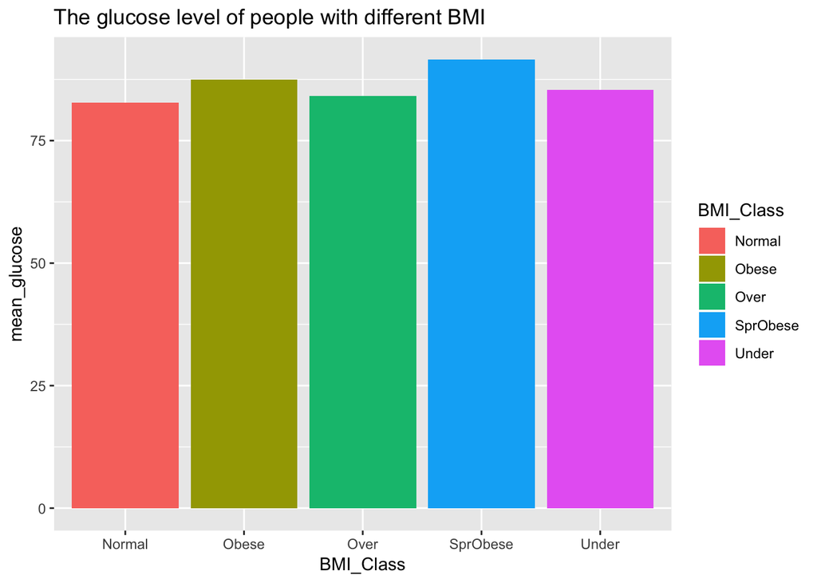

```r
# SUMMARY OF Mean Glucose Levels by BMI category
frm_bmi_glu <- frm_mod %>% filter(!is.na(GLUCOSE) & !is.na(BMI)) %>%
  group_by(BMI_Class) %>%
  summarise (mean_glucose=mean(GLUCOSE))

ggplot(frm_bmi_glu,aes(BMI_Class,mean_glucose,fill=BMI_Class)) +
  geom_bar(stat="identity",position="dodge") +
  ggtitle("The glucose level of people with different BMI")
```

```r
# SUMMARY OF percentage pf diabetes by BMI category and SEX
frm_bmi_dia <- frm_mod %>% filter(!is.na(DIABETES) & !is.na(BMI) & DIABETES == 1) %>%
  group_by(BMI_Class,SEX) %>%
  summarise (n=length(DIABETES))  %>%
  mutate(freq = n / sum(n))
head(frm_bmi_dia)
```

```
## # A tibble: 6 x 4
## # Groups:   BMI_Class [3]
##   BMI_Class   SEX     n  freq
##   <chr>     <int> <int> <dbl>
## 1 Normal        1    82 0.485
## 2 Normal        2    87 0.515
## 3 Obese         1    32 0.360
## 4 Obese         2    57 0.640
## 5 Over          1   121 0.565
## 6 Over          2    93 0.435
```

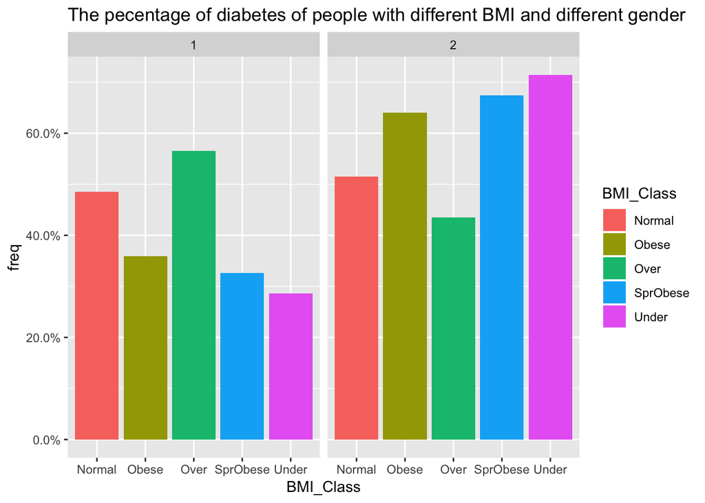

```r
ggplot(frm_bmi_dia,aes(BMI_Class,freq,fill=BMI_Class)) +
  geom_bar(stat="identity",position="dodge") +
  ggtitle("The pecentage of diabetes of people with different BMI and different gender")+
  scale_y_continuous(labels = percent) +
  facet_grid(.~SEX)
```

## Intial Analysis

Checking the distribution of different traits based on the education

```r
frm %>% group_by(educ) %>% filter(!is.na(BMI),!is.na(educ)) %>% summarise(mean_bmi=mean(BMI))
```

```
## # A tibble: 4 x 2
##    educ mean_bmi
##   <int>    <dbl>
## 1     1     26.6
## 2     2     25.5
## 3     3     25.0
## 4     4     25.3
```

```r
frm %>% group_by(educ) %>% filter(!is.na(HEARTRTE),!is.na(educ)) %>% summarise(mean_heart_rate=mean(HEARTRTE))
```

```
## # A tibble: 4 x 2
##    educ mean_heart_rate
##   <int>           <dbl>
## 1     1            77.0
## 2     2            77.6
## 3     3            76.8
## 4     4            74.2
```

```r
frm %>% group_by(educ) %>% filter(!is.na(GLUCOSE),!is.na(educ)) %>% summarise(mean_glucose=mean(GLUCOSE))
```

```
## # A tibble: 4 x 2
##    educ mean_glucose
##   <int>        <dbl>
## 1     1         85.9
## 2     2         83.3
## 3     3         83.0
## 4     4         82.3
```

## Discussion for initial analysis

we analysed the framigham data set to check how a socieconomic status and access to higher levels of education affected factors such as bmi(body mass index),heart rate and glucose level(we assessed glucose levels because constant high glucose level(hyperglycemia) are correlated with high risk for certain lifestyle diseases.

Blood glucose levels range from 90 to 130 mg/dL before meals, and below 180 mg/dL within 1 to 2 hours after a meal. In general, most people without diabetes have blood sugar levels before meals hover around 70 to 80 mg/dL: 60 is normal; for others, 90.Hypoglycemia, also called low blood glucose or low blood sugar, occurs when the level of glucose in your blood drops below normal. For many people with diabetes, that means a level of 70 milligrams per deciliter (mg/dL) or less. Glucose: the mean glucose levels decreased as education levels increased. Higher education levels were associated with lower and slightly healthier glucose levels. Overall, the mean glucose levels for all groups were fell within a healthy range for glucose levels.

## Logistic Models

Some of the early logistic models

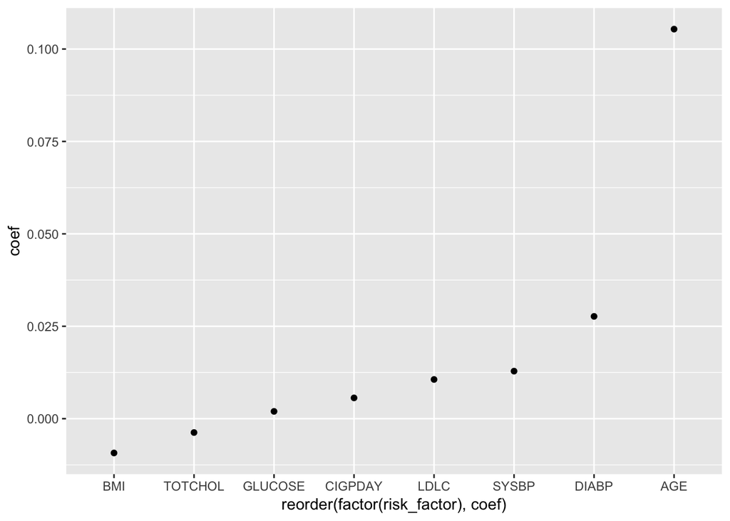

```r
#Predicting presence of Coronary Heart Disease using risk factors
beta <- coef(glm(PREVCHD ~ BMI + TOTCHOL + AGE + SYSBP + GLUCOSE + CIGPDAY + LDLC,data=frm,family=binomial()))

#Predicting prevalence of Stroke using risk factors
beta_1 <- coef(glm(PREVSTRK ~ BMI + TOTCHOL + AGE + SYSBP + DIABP + GLUCOSE + CIGPDAY + LDLC,data=frm,family=binomial()))

preval_chd <- as.tibble(as.list(beta[-1])) %>% gather(risk_factor,coef)

preval_strk <- as.tibble(as.list(beta_1[-1])) %>% gather(risk_factor,coef)

ggplot(preval_strk,aes(reorder(factor(risk_factor), coef), coef)) + geom_point()
```

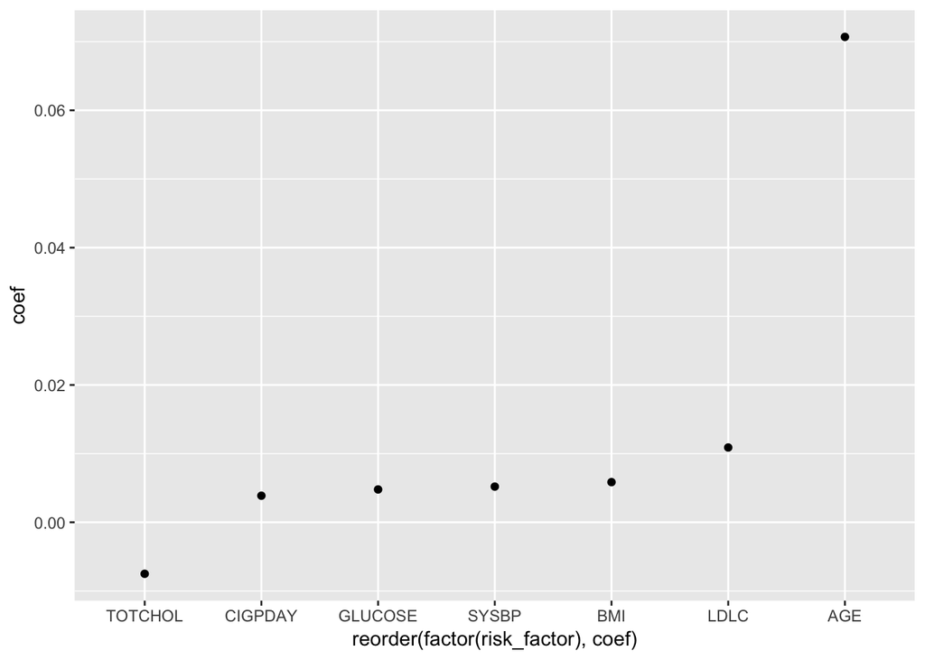

```r
ggplot(preval_chd,aes(reorder(factor(risk_factor), coef), coef)) + geom_point()
```

## Discussion for the first logistic regression model For this part,we used a logistic regression model to predict the presence of Coronary Heart Disease using risk factors such as BMIBody Mass Index(BMI), TOTCHOL(Total Cholestrol levels), AGE(Age), Systolic Blood Pressure(SYSBP), GLUCOSE, the number of cigarettes per day(CIGPDAY) and Blood levels of Low-density lipoprotein (LDL) is one of the body’s lipoproteins and an important carrier of cholesterol.LDL cholesterol (LDL-C) are often assessed when evaluating the risk of future heart disease.

AGE:From our model, age was the highest risk factor for predicting the presence of Coronary Heart Disease. It would be expected that the older one gets, the higher the risk for developing chronic and lifestyle diseases.

Another important distinction was noted between TOTAL CHOL level and LDLC levels. One would expect higher levels of total cholestrol(TOTCHOL) to be a higher predictor but using logistic regression model to asses the framigham dataset, Higher Levels of Low-density lipoprotein (LDL) put one at a higher risk of cornary heart disease more than the former.

## BMI Based Categorisation

```r
frmgham_mod<- frm %>%
  mutate(BMI_Class=case_when(BMI<18.5~'Underweight',BMI >= 18.5 & BMI <25 ~ 'Normal',BMI >= 25 & BMI < 30 ~ 'Overweight',BMI>=30 & BMI<35 ~ 'Obese',BMI>=35 ~ 'Super Obese'))

# SUMMARY OF Mean Heart Rates by BMI category
frmgham_mod %>% group_by(BMI_Class) %>% filter(!is.na(HEARTRTE) & !is.na(BMI)) %>% summarise(mean_heart_rate=mean(HEARTRTE))
```

```
## # A tibble: 5 x 2
##   BMI_Class   mean_heart_rate
##   <chr>                 <dbl>
## 1 Normal                 76.3
## 2 Obese                  78.4
## 3 Overweight             76.4
## 4 Super Obese            81.6
## 5 Underweight            80.7
```

```r
# SUMMARY OF Mean Glucose Levels by BMI category
frmgham_mod %>% group_by(BMI_Class) %>% filter(!is.na(GLUCOSE) & !is.na(BMI)) %>% summarise()
```

```
## # A tibble: 5 x 1
##   BMI_Class
##   <chr>
## 1 Normal
## 2 Obese
## 3 Overweight
## 4 Super Obese
## 5 Underweight
```

```r
frmgham_mod %>% filter(!is.na(GLUCOSE)) %>% group_by(BMI_Class) %>% summarise(count=n())
```

```
## # A tibble: 6 x 2
##   BMI_Class   count
##   <chr>       <int>
## 1 Normal       4452
## 2 Obese        1068
## 3 Overweight   4229
## 4 Super Obese   264
## 5 Underweight   139
## 6 <NA>           35
```

```r
frmgham_mod <- frmgham_mod %>% mutate(pulse_pressure=SYSBP-DIABP)
```

## Looking at the healthy subset of the people

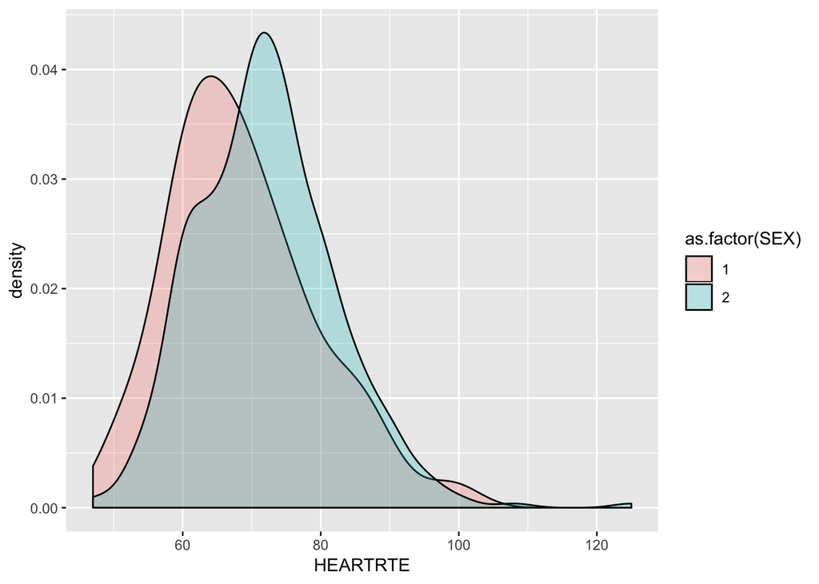

```r
# Create a subset of healthy individuals
healthy_set <- frmgham_mod %>% filter(CURSMOKE == 0, DIABP < 80, SYSBP < 120, DIABETES == 0,DEATH==0,BMI_Class=='Normal')

# Heart rate distribution in healthy people
ggplot(healthy_set, aes(x = HEARTRTE,fill = as.factor(SEX))) +
  #geom_histogram(color = "red", fill = "white") +
  geom_density(alpha = 0.25)
```

##Discussion for the last graph Looking at the healthy subset of the people For this part, we created a subset(class) using of healthy individuals from our dataset by assigning normal ranges associated with good health for the risk factors: These were no smoking, a diastolic blood pressure reading of less than 80(DIABP < 80), a systolic blood pressure reading of less than 120(SYSBP < 120), no presence of diabetes(DIABETES= 0), no death(DEATH=0), and a normal Body Mass Index(BMI_Class==‘Normal’). We then used this factors to look at the heart rate for different sexes. From our assesment, after normalizing all risk factors, one sex still had a higher heart rate than the other.

## Pulse pressure

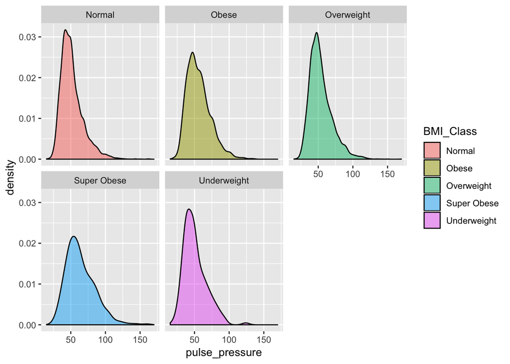

```r
frmgham_mod %>% filter(!is.na(BMI_Class)) %>% ggplot(aes(pulse_pressure,fill=BMI_Class)) + geom_density(alpha=0.5) + facet_wrap(~BMI_Class,nrow=2)
```